# Project Python for Data Science: Austo Motor Company Analysis

**Context**

Analysts are required to explore data and reflect on the insights. Clear writing skill is an integral part of a good report. Note that the explanations must be such that readers with minimum knowledge of analytics is able to grasp the insight.

Austo Motor Company is a leading car manufacturer specializing in SUV, Sedan, and Hatchback models. In its recent board meeting, concerns were raised by the members on the efficiency of the marketing campaign currently being used. The board decides to rope in an analytics professional to improve the existing campaign.

**Objective**

They want to analyze the data to get a fair idea about the demand of customers which will help them in enhancing their customer experience. Suppose you are a Data Scientist at the company and the Data Science team has shared some of the key questions that need to be answered. Perform the data analysis to find answers to these questions that will help the company to improve the business.

**Data Description**

**Age**: The age of the individual in years.  
**Gender**: The gender of the individual, categorized as male or female.  
**Profession**: The occupation or profession of the individual.  
**Marital_status**: The marital status of the individual, such as married &, single  
**Education**: The educational qualification of the individual Graduate and Post Graduate  
**No_of_Dependents**: The number of dependents (e.g., children, elderly parents) that the individual supports financially.  
**Personal_loan**: A binary variable indicating whether the individual has taken a personal loan "Yes" or "No"  
**House_loan**: A binary variable indicating whether the individual has taken a housing loan "Yes" or "No"  
**Partner_working**: A binary variable indicating whether the individual's partner is employed "Yes" or "No"  
**Salary**: The individual's salary or income.  
**Partner_salary**: The salary or income of the individual's partner, if applicable.  
**Total_salary**: The total combined salary of the individual and their partner (if applicable).  
**Price**: The price of a product or service.  
**Make**: The type of automobile

```python
# importing the libraries to help the reading and manipulating the data set
import pandas as pd
import numpy as np

# Libraries to help data visualization of dataset
import matplotlib.pyplot as plt
import seaborn as sns

# We are ristricting the float value upto 2 decimal places
pd.set_option('display.float_format', lambda x: '%.2f' % x)
```

```python
# Giving colab access my google drive
from google.colab import drive
drive.mount('/content/drive')
```

```python
# Importing and loading the dataset of austo_automobile
df = pd.read_csv('/content/drive/MyDrive/DS & BA/PYTHON FOR DS/GL Projects/2. Automobile/austo_automobile.csv', na_values = ["missing", "inf"])
```

### Data Overview

```python
# Viewing first five row of dataset
df.head()
```

|  | Age | Gender | Profession | Marital_status | Education | No_of_Dependents | Personal_loan | House_loan | Partner_working | Salary | Partner_salary | Total_salary | Price | Make |
| --- | --- | --- | --- | --- | --- | --- | --- | --- | --- | --- | --- | --- | --- | --- |
| 0 | 53 | Male | Business | Married | Post Graduate | 4 | No | No | Yes | 99300 | 70700.00 | 170000 | 61000 | SUV |
| 1 | 53 | Femal | Salaried | Married | Post Graduate | 4 | Yes | No | Yes | 95500 | 70300.00 | 165800 | 61000 | SUV |
| 2 | 53 | Female | Salaried | Married | Post Graduate | 3 | No | No | Yes | 97300 | 60700.00 | 158000 | 57000 | SUV |
| 3 | 53 | Female | Salaried | Married | Graduate | 2 | Yes | No | Yes | 72500 | 70300.00 | 142800 | 61000 | SUV |
| 4 | 53 | Male | Salaried | Married | Post Graduate | 3 | No | No | Yes | 79700 | 60200.00 | 139900 | 57000 | SUV |

- Printing the first five rows of the dataset

```python
df.tail()
```

|  | Age | Gender | Profession | Marital_status | Education | No_of_Dependents | Personal_loan | House_loan | Partner_working | Salary | Partner_salary | Total_salary | Price | Make |
| --- | --- | --- | --- | --- | --- | --- | --- | --- | --- | --- | --- | --- | --- | --- |
| 1576 | 22 | Male | Salaried | Single | Graduate | 2 | No | Yes | No | 33300 | 0.00 | 33300 | 27000 | Hatchback |
| 1577 | 22 | Male | Business | Married | Graduate | 4 | No | No | No | 32000 | NaN | 32000 | 31000 | Hatchback |
| 1578 | 22 | Male | Business | Single | Graduate | 2 | No | Yes | No | 32900 | 0.00 | 32900 | 30000 | Hatchback |
| 1579 | 22 | Male | Business | Married | Graduate | 3 | Yes | Yes | No | 32200 | NaN | 32200 | 24000 | Hatchback |
| 1580 | 22 | Male | Salaried | Married | Graduate | 4 | No | No | No | 31600 | 0.00 | 31600 | 31000 | Hatchback |

- Printing the last five rows of the dataset

```python
# Check the shape of the dataset
df.shape
# checking shape of the data
print("There are", df.shape[0], 'rows and', df.shape[1], "columns.")
```

```
There are 1581 rows and 14 columns.
```

```python
# Checking the data types of the columns for the data set
df.info()
```

```
<class 'pandas.core.frame.DataFrame'>
RangeIndex: 1581 entries, 0 to 1580
Data columns (total 14 columns):
 #   Column            Non-Null Count  Dtype
---  ------            --------------  -----
 0   Age               1581 non-null   int64
 1   Gender            1528 non-null   object
 2   Profession        1581 non-null   object
 3   Marital_status    1581 non-null   object
 4   Education         1581 non-null   object
 5   No_of_Dependents  1581 non-null   int64
 6   Personal_loan     1581 non-null   object
 7   House_loan        1581 non-null   object
 8   Partner_working   1581 non-null   object
 9   Salary            1581 non-null   int64
 10  Partner_salary    1475 non-null   float64
 11  Total_salary      1581 non-null   int64
 12  Price             1581 non-null   int64
 13  Make              1581 non-null   object
dtypes: float64(1), int64(5), object(8)
memory usage: 173.0+ KB
```

- There are 6 numerical coulmns (1 column is of float types and 5 columns are of int type) in the data set and 8 object types of columns in dataset austo motors.
- We observe that some columns have less entries than the other columns which indicates the presence of missing values in the data and specially in column (Gender and Partner_salary)
- The memory uses are 173.0 + KB

```python
# Checking the Duplicate value in dataset
df.duplicated().sum()
```

```
0
```

- There are 0 duplicates value in dataset

# Checking Unique Value of all the Categorical Variables

```python
list_cat = ["Gender", "Profession", "Marital_status", "Education", "Personal_loan", "House_loan", "Partner_working", "Make"]
for column in list_cat:
    print("The Unique value of ", column,"are :", df[column].unique())
    print("." * 40)
```

```
The Unique value of  Gender are : ['Male' 'Femal' 'Female' nan 'Femle']
........................................
The Unique value of  Profession are : ['Business' 'Salaried']
........................................
The Unique value of  Marital_status are : ['Married' 'Single']
........................................
The Unique value of  Education are : ['Post Graduate' 'Graduate']
........................................
The Unique value of  Personal_loan are : ['No' 'Yes']
........................................
The Unique value of  House_loan are : ['No' 'Yes']
........................................
The Unique value of  Partner_working are : ['Yes' 'No']
........................................
The Unique value of  Make are : ['SUV' 'Sedan' 'Hatchback']
........................................
```

```python
# as female word written in 3 different spelling, replacing the Femal and Femle data with correct spelling Female
df["Gender"] = df["Gender"].replace({"Femal": "Female", "Femle": "Female"})
print(df["Gender"].unique())
```

```
['Male' 'Female' nan]
```

- After replacing the femal, femle data with correct spelling , we are seeing the the geneder are divided into 3 category Male , Female and Nan. there are some missing value is there

# Checking Null Value in the dataset

```python
# Calculate the number of null values and their percentage
pd.DataFrame({'Null Value Count':df.isnull().sum()[df.isnull().sum()>0],'% of Null Value':(df.isnull().sum()[df.isnull().sum()>0]/df.shape[0])*100})
```

|  | Null Value Count | % of Null Value |
| --- | --- | --- |
| Gender | 53 | 3.35 |
| Partner_salary | 106 | 6.70 |

- There is missing value in gender (53) (3.35%) and partner_salary(106)(6.70%)

```python
# Treating missing value in Gender column
df["Gender"].value_counts(normalize = True, dropna = False)
```

```
Gender
Male     0.76
Female   0.21
NaN      0.03
Name: proportion, dtype: float64
```

- As we can see that there is missing value 3% in Gender Column
- The percentage of missing values is very less than the percentage of observations from other Gender.
- We can treat the missing values with a separate category for this variable as it is very less

```python
# Replacing NaN with Unknown
df['Gender'].fillna('Gender_Unknown', inplace =True)
```

```python
# Treating missing value in Gender column
df["Gender"].value_counts(normalize = True, dropna = False)
```

```
Gender
Male             0.76
Female           0.21
Gender_Unknown   0.03
Name: proportion, dtype: float64
```

```python
df["Gender"].unique()
```

```
array(['Male', 'Female', 'Gender_Unknown'], dtype=object)
```

- New label has been updated in Gender column i.e Gender Unknown

```python
df.isnull().sum()
```

```
Age                   0
Gender                0
Profession            0
Marital_status        0
Education             0
No_of_Dependents      0
Personal_loan         0
House_loan            0
Partner_working       0
Salary                0
Partner_salary      106
Total_salary          0
Price                 0
Make                  0
dtype: int64
```

The missing values in the Gender column have been treated. Let us now move on to Partner_salary variable and see how to deal with the missing values present there.

Since Partner_salary is a numerical variable, so we can impute the missing values by mean or median but before imputation, let's analyze the Partner_salary variable in detail.

Let us print the rows where the Partner_salary variable is having missing values.

```python
df.loc[df["Partner_salary"].isnull()==True]
```

|  | Age | Gender | Profession | Marital_status | Education | No_of_Dependents | Personal_loan | House_loan | Partner_working | Salary | Partner_salary | Total_salary | Price | Make |
| --- | --- | --- | --- | --- | --- | --- | --- | --- | --- | --- | --- | --- | --- | --- |
| 40 | 53 | Female | Salaried | Married | Graduate | 1 | Yes | No | No | 72100 | NaN | 72100 | 60000 | SUV |
| 43 | 52 | Male | Salaried | Married | Post Graduate | 3 | No | No | Yes | 87600 | NaN | 88200 | 51000 | SUV |
| 49 | 52 | Female | Business | Married | Post Graduate | 4 | No | No | Yes | 90300 | NaN | 170400 | 69000 | SUV |
| 59 | 54 | Male | Salaried | Married | Graduate | 3 | Yes | No | Yes | 80600 | NaN | 81000 | 51000 | SUV |
| 111 | 48 | Female | Business | Married | Graduate | 3 | No | No | Yes | 90300 | NaN | 161100 | 62000 | SUV |
| ... | ... | ... | ... | ... | ... | ... | ... | ... | ... | ... | ... | ... | ... | ... |
| 1559 | 22 | Male | Business | Married | Post Graduate | 3 | Yes | No | No | 52100 | NaN | 52100 | 28000 | Hatchback |
| 1567 | 22 | Male | Salaried | Single | Graduate | 0 | Yes | Yes | No | 39700 | NaN | 39700 | 23000 | Hatchback |
| 1568 | 22 | Male | Salaried | Married | Graduate | 3 | No | Yes | No | 38000 | NaN | 38000 | 23000 | Sedan |
| 1577 | 22 | Male | Business | Married | Graduate | 4 | No | No | No | 32000 | NaN | 32000 | 31000 | Hatchback |
| 1579 | 22 | Male | Business | Married | Graduate | 3 | Yes | Yes | No | 32200 | NaN | 32200 | 24000 | Hatchback |

106 rows × 14 columns

```python
# Calculate Partner_salary for missing values using Total_salary - Salary
df.loc[df['Partner_salary'].isnull()==True, 'Partner_salary'] = df['Total_salary'] - df['Salary']
```

```python
# Verify that there are no more missing values in the Partner_salary column
df.isnull().sum()
```

```
Age                 0
Gender              0
Profession          0
Marital_status      0
Education           0
No_of_Dependents    0
Personal_loan       0
House_loan          0
Partner_working     0
Salary              0
Partner_salary      0
Total_salary        0
Price               0
Make                0
dtype: int64
```

# Statical summary of Numerical Variables

```python
df.describe().T
```

|  | count | mean | std | min | 25% | 50% | 75% | max |
| --- | --- | --- | --- | --- | --- | --- | --- | --- |
| Age | 1581.00 | 31.92 | 8.43 | 22.00 | 25.00 | 29.00 | 38.00 | 54.00 |
| No_of_Dependents | 1581.00 | 2.46 | 0.94 | 0.00 | 2.00 | 2.00 | 3.00 | 4.00 |
| Salary | 1581.00 | 60392.22 | 14674.83 | 30000.00 | 51900.00 | 59500.00 | 71800.00 | 99300.00 |
| Partner_salary | 1581.00 | 19233.78 | 19670.39 | 0.00 | 0.00 | 25100.00 | 38100.00 | 80500.00 |
| Total_salary | 1581.00 | 79626.00 | 25545.86 | 30000.00 | 60500.00 | 78000.00 | 95900.00 | 171000.00 |
| Price | 1581.00 | 35597.72 | 13633.64 | 18000.00 | 25000.00 | 31000.00 | 47000.00 | 70000.00 |

**Age**: On an average age of an individuals are 31 yrs, 50% of the individual are of 29 yrs. in this dataset. 75% of an individual having age less than or equal to 38 yrs. The minimum and the maximum age of an individual are 22 yrs. and 54 yrs. respectively.

**No_of_Dependents**: There are 0 no of dependents and few of the dependents is having up to 4 dependents. On an average there are 2 no of dependents of customer are available in dataset. 75% of an individual are having less than or equal to 3 dependents.

**Salary**: The range of salary from 30,000 to 99,300. 50 % of salary distribution are 59,000. 75% of the salary are less than or equal to 71,800. It is noticeable that there are diverse income levels of the customer.

**Price**: on an average the price of car is 35597. Median of the price of car is 31,000

# Univariate Analysis

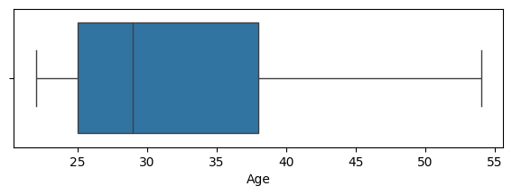

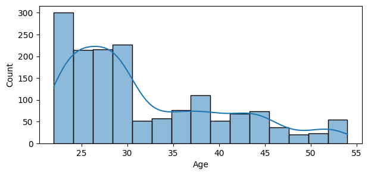

```python
plt.figure(figsize=(7,2))
sns.boxplot(data=df,x='Age')
plt.show()
plt.figure(figsize=(7,3))
sns.histplot(data=df,x='Age', kde = "True")
plt.show()
```

- The distribution of Age is little right skewed.
- There is no outliers present in the Age columns , that means , The age are in the same .
- The age group where customer likes car is in between 20 yrs to 54 yrs. 50% of the data of Age lies under 30 yrs.

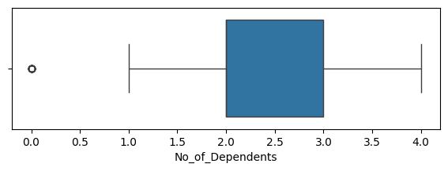

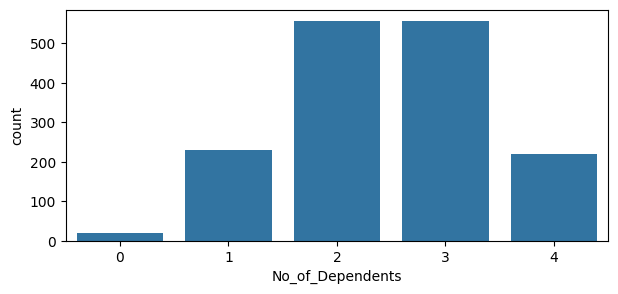

```python
plt.figure(figsize=(7,2))
sns.boxplot(data=df,x='No_of_Dependents')
plt.show()
plt.figure(figsize=(7,3))
sns.countplot(data=df,x='No_of_Dependents')
plt.show()
```

- Representing the number of dependents for each individuals
- range of no of dependents are from 0 to 4.

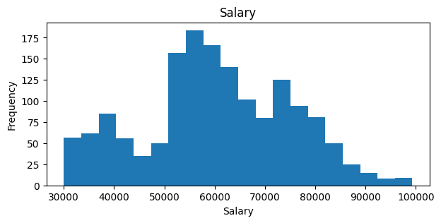

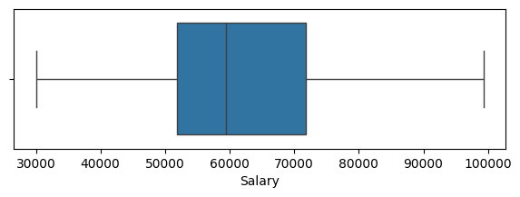

```python
plt.figure(figsize=(7,3))
df['Salary'].plot(kind='hist', bins=20, title='Salary')
plt.xlabel("Salary")
plt.show()
plt.figure(figsize=(7,2))
sns.boxplot(data=df,x='Salary')
plt.show()
```

- it is representating the salary of an individual
- The range os salary are from 30000 to 99000

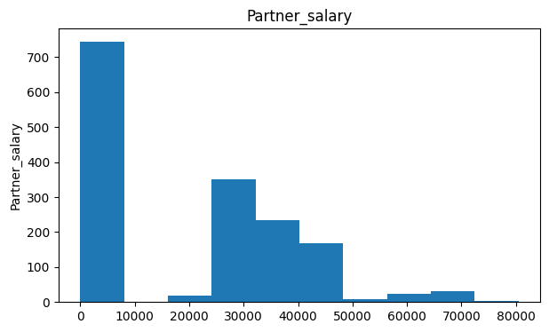

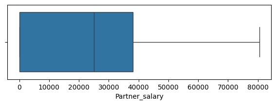

```python
df['Partner_salary'].plot(kind='hist', figsize=(7, 4), title='Partner_salary')
plt.ylabel('Partner_salary')
plt.show()
plt.figure(figsize=(7,2))
sns.boxplot(data=df,x='Partner_salary')
plt.show()
```

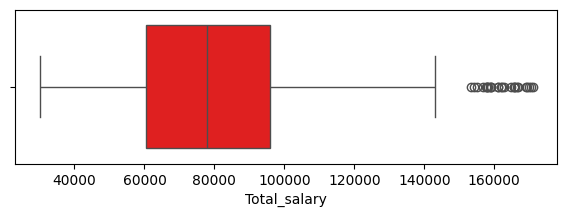

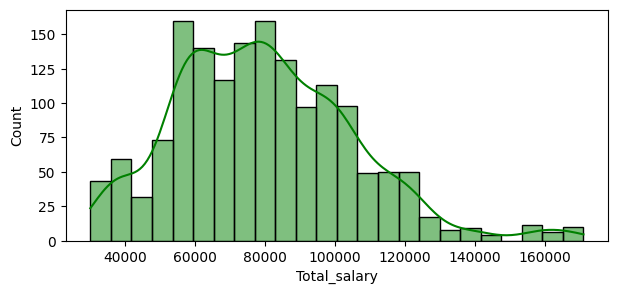

```python
plt.figure(figsize=(7,2))
sns.boxplot(data=df,x='Total_salary', color = "r")
plt.show()
plt.figure(figsize=(7,3))
sns.histplot(data=df,x='Total_salary', color = "g", kde = True)
plt.show()
```

Description: Combined salary of the individual and their partner. Statistics: Range: 30,000 to 171,000 Mean: 79,626 Median: 78,000

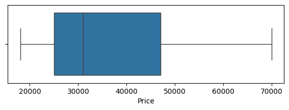

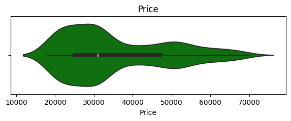

```python
plt.figure(figsize=(7,2))
sns.boxplot(data=df,x='Price')
plt.show()
plt.figure(figsize=(7,2))
sns.violinplot(data=df,x='Price', color = "g")
plt.title("Price")
plt.show()
```

Description: Price of the automobile. Statistics: Range: 18,000 to 70,000 Mean: 35,598 Median: 31,000

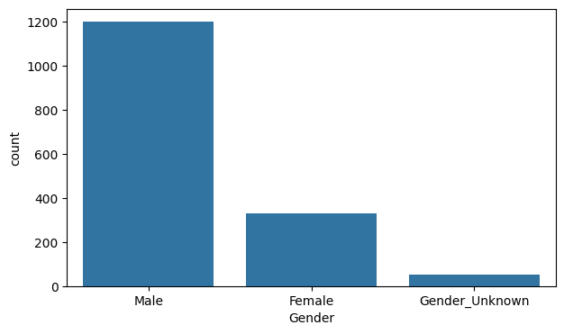

```python
plt.figure(figsize=(7,4))
sns.countplot(data=df,x='Gender')
plt.xticks(rotation = 0)
plt.show()
```

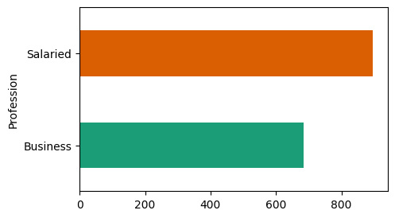

```python
plt.figure(figsize=(5,3))
df.groupby('Profession').size().plot(kind='barh', color=sns.palettes.mpl_palette('Dark2'))
xlabel="count"
plt.gca()
```

[output not shown]

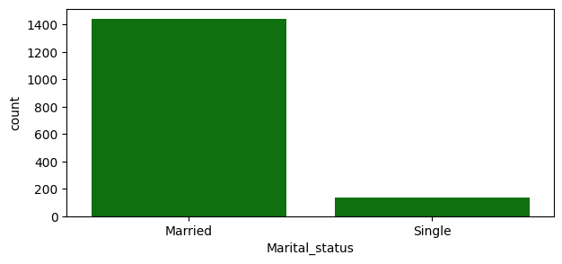

```python
plt.figure(figsize=(7,3))
sns.countplot(data=df,x='Marital_status', color = "g")
plt.xticks(rotation = 0)
```

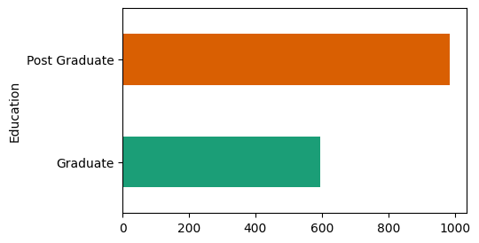

```python
plt.figure(figsize=(5,3))
df.groupby('Education').size().plot(kind='barh', color=sns.palettes.mpl_palette('Dark2'))
plt.gca()
```

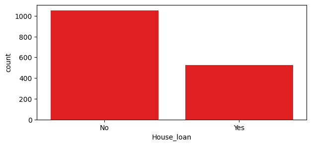

```python
plt.figure(figsize=(7,3))
sns.countplot(data=df,x='House_loan', color = "r")
```

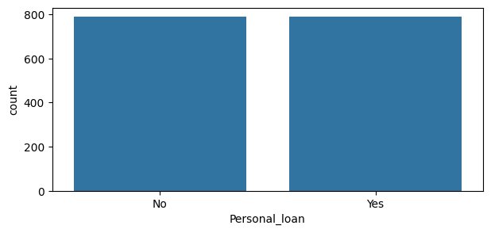

```python
plt.figure(figsize=(7,3))
sns.countplot(data=df,x='Personal_loan')
```

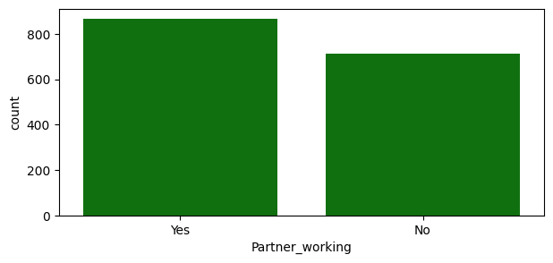

```python
plt.figure(figsize=(7,3))
sns.countplot(data=df,x='Partner_working', color = "g")
```

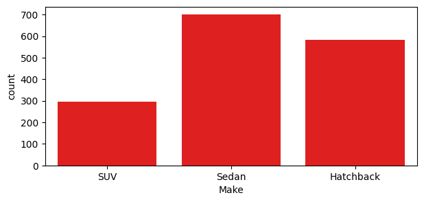

```python
plt.figure(figsize=(7,3))
sns.countplot(data=df, x='Make', color = "r")  # Use palette instead of color
plt.xticks(rotation=0)
plt.xlabel("Make")
plt.show()
```

Make

Type: Object (Categorical) Description: Type of automobile. Unique Values: SUV, Sedan, Hatchback Mode: Sedan (702 entries)

### Outlier Detection and Treatment

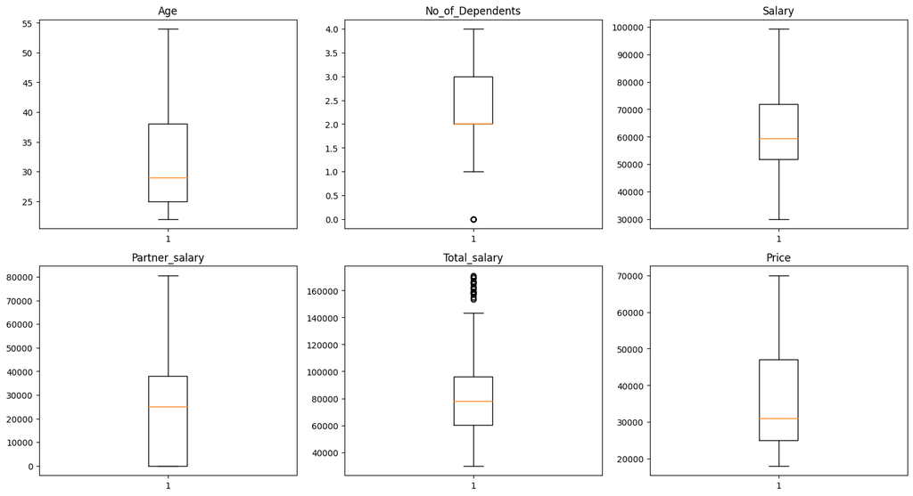

```python
# outlier detection using boxplot
# selecting the numerical columns of data and adding their names in a list
numeric_columns = ['Age','No_of_Dependents','Salary','Partner_salary','Total_salary', 'Price']
plt.figure(figsize=(15, 12))

for i, variable in enumerate(numeric_columns):
    plt.subplot(3, 3, i + 1)
    plt.boxplot(df[variable], whis=1.5)
    plt.tight_layout()
    plt.title(variable)

plt.show()
```

```python
num_columns = ['Age','No_of_Dependents','Salary','Partner_salary','Total_salary', 'Price']
Q1 = df[num_columns].quantile(0.25)
Q3 = df[num_columns].quantile(0.75)

IQR = Q3 - Q1
lower_whisker = Q1 - 1.5*IQR
upper_whisker = Q3 + 1.5*IQR
```

```python
# Percentage of outliers in each column
((df[num_columns] < lower_whisker) | (df[num_columns] > upper_whisker)).sum()
```

```
Age                  0
No_of_Dependents    20
Salary               0
Partner_salary       0
Total_salary        27
Price                0
dtype: int64
```

```python
def treat_outliers(df, col):

    Q1 = df[col].quantile(0.25)  # 25th quantile
    Q3 = df[col].quantile(0.75)  # 75th quantile
    IQR = Q3 - Q1                # Inter Quantile Range (75th perentile - 25th percentile)

    # all the values smaller than lower_whisker will be assigned the value of lower_whisker
    lower_whisker = Q1 - 1.5 * IQR
    # all the values greater than upper_whisker will be assigned the value of upper_whisker
    upper_whisker = Q3 + 1.5 * IQR

    # the assignment will be done by using the clip function of NumPy
    df[col] = np.clip(df[col], lower_whisker, upper_whisker)

    return df
```

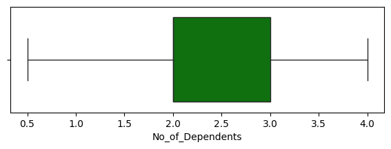

```python
plt.figure(figsize=(7,2))
data = treat_outliers(df,'No_of_Dependents')
# visualizing the column after outlier treatment
sns.boxplot(data=df,x='No_of_Dependents', color = "g")
plt.show()
```

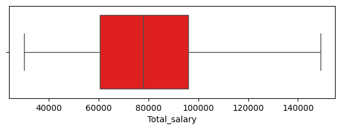

```python
plt.figure(figsize=(7,2))
data = treat_outliers(df,'Total_salary')
# visualizing the column after outlier treatment
sns.boxplot(data=df,x='Total_salary', color = "r")
plt.show()
```

# Bivariate Analysis

Bivariate Analysis of Numerical Variables

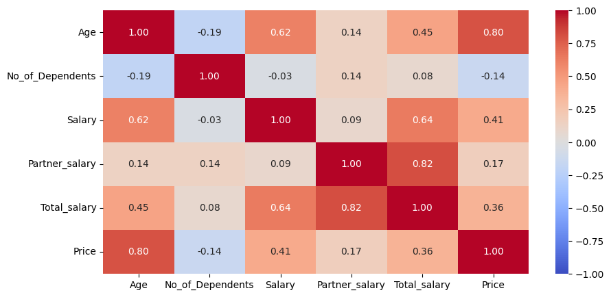

```python
# Check for correlation among numerical variables
num_var = ['Age','No_of_Dependents','Salary','Partner_salary','Total_salary', 'Price']

# plot the heatmap

plt.figure(figsize=(10, 5))
sns.heatmap(df[num_var].corr(), annot=True, vmin=-1, vmax=1, fmt=".2f", cmap="coolwarm")
plt.show()
```

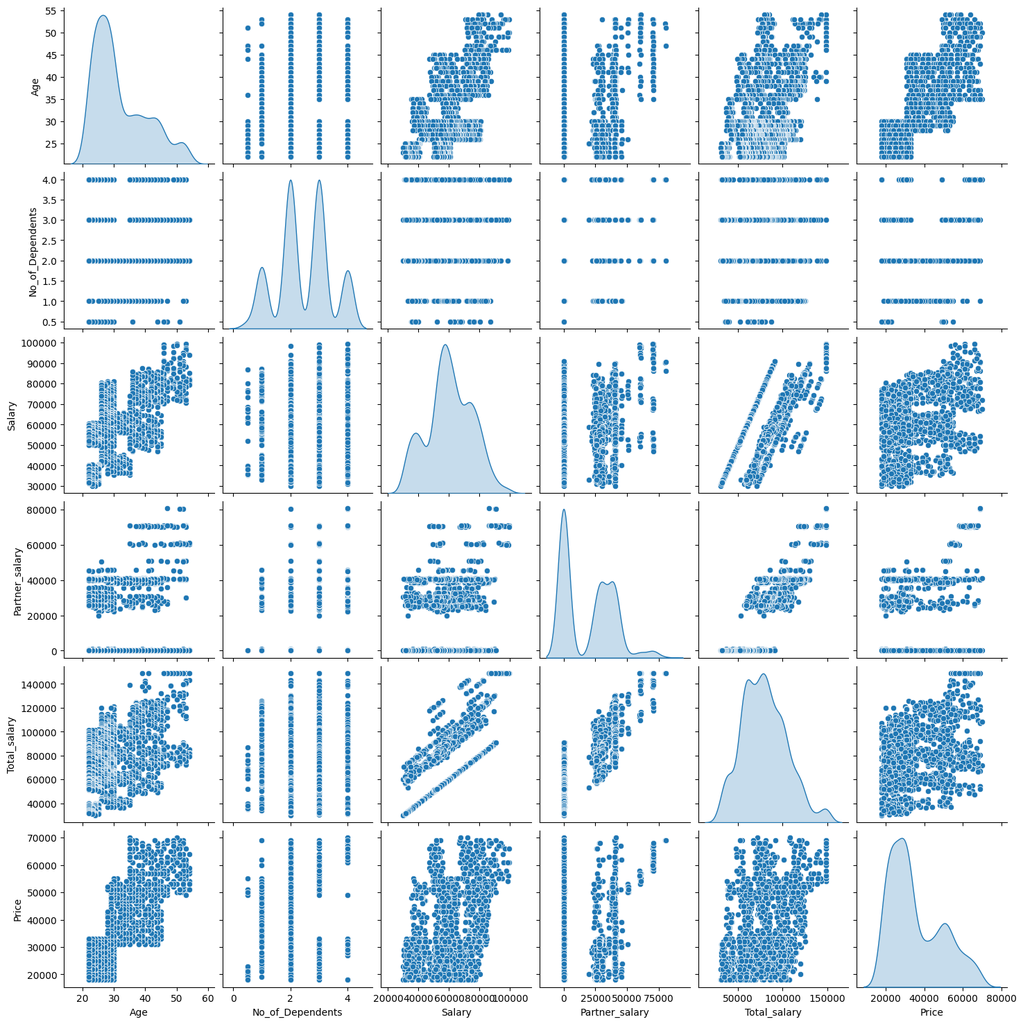

```python
# Check for correlation among numerical variables
num_var = ['Age','No_of_Dependents','Salary','Partner_salary','Total_salary', 'Price']

sns.pairplot(data=df[num_var], diag_kind="kde")
plt.show()
```

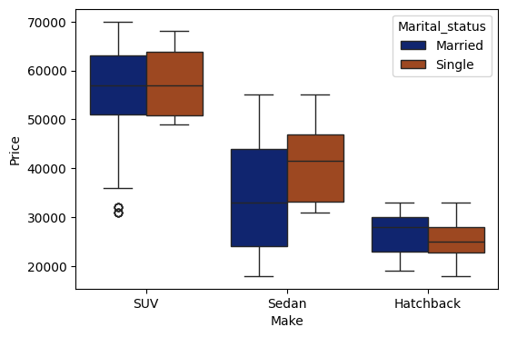

```python
plt.figure(figsize=(6,4))
sns.boxplot(data=df,x='Make', y = "Price" ,palette="dark", hue = "Marital_status")
plt.show()
```

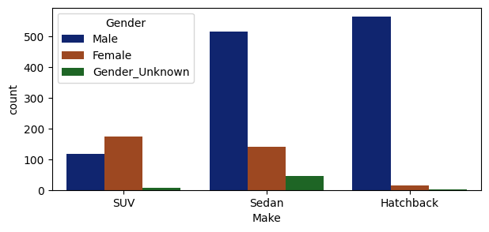

```python
plt.figure(figsize=(7,3))
sns.countplot(x='Make', data=df, hue = "Gender", palette="dark")
plt.show()
```

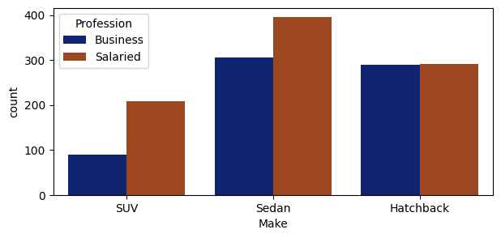

```python
plt.figure(figsize=(7,3))
sns.countplot(x='Make', data=df, hue = "Profession", palette="dark")
plt.show()
```